# Response diversity diversity measure check

Author

Owen L. Petchey

# 1 Introduction

[Ross et al (2023)](https://besjournals.onlinelibrary.wiley.com/doi/10.1111/2041-210X.14087) introduced a couple of measures of response diversity. One, dissimilarity, measures the dispersion of response traits. The other, divergence, included information about the sign of the traits, and has a higher value if some species have positive response traits values and some have negative response trait values. The divergence measure is lower if all species have positive response trait values (or all have negative response trait values).

The motivation for the divergence measure was that it is relevant and important for system stability (e.g., temporal variation of total biomass) if some species have positive and some negative responses, and that knowing the spread alone would not be as relevant for system stability. [Ross et al (2023)](https://besjournals.onlinelibrary.wiley.com/doi/10.1111/2041-210X.14087) did, indeed, find that divergence was in one laboratory experiment a better predictor of biomass temporal stability than dissimilarity.

The specific measure of divergence was:

$$Divergence = \frac{ (max[f'(E)] - min[f'(E)]) - ||max[f'(E)]|-|min[f'(E)]||
}{(max[f'(E)] - min[f'(E)])}$$

Table 1. Six sets of response trait values and their respective measures of dissimilarity, divergence, and mean.

| Case | Response traits | Dissimilarity | Divergence | Mean |
| --- | --- | --- | --- | --- |
| 1 | 1,2,3 | 1.9 | 0 | 2 |
| 2 | -1,-2,-3 | 1.9 | 0 | -2 |
| 3 | 5,6,7 | 1.9 | 0 | 6 |
| 4 | 3,0,-3 | 2.8 | 1 | 0 |
| 5 | 3,2,-3 | 2.4 | 1 | 0.7 |
| 6 | 3,0,-1 | 2.4 | 0.5 | 0.7 |

Table 1 shows that divergence is 0 when all trait values are positive (first row) or are all negative (second row). The third row shows that divergence remains zero even when the mean changes, so long as all traits values remain of one sign. The fourth row shows a case where there are negative and positive trait values, and the most negative is the same distance from zero as the most positive, thus giving a divergence value of 1 (the maximum value possible). The fifth row shows a case where divergence is also 1 (because again the most negative trait values is the same distance from zero as the most positive) but where the mean is different because one of the other trait values is different. The sixth row shows a case where the mean trait value is the same as in the fifth row, though the divergence value is different.

For the purposes of predicting changes in total community biomass, and if these traits are change in growth rate, we might expect the case in the first row to have a lower change in total biomass than the case in the third row. This is because the case in the third row represents a much greater increase in intrinsic growth rate. This difference between the first and third case is not represented in the dissimilarity or divergence measure, but is represented in the mean.

Similarly, case 4 and 5 have the same value of divergence, but 5 has a greater mean. This is because in case 4 one species has a 0 response trait value, while in case 5 it has a values of 2. The other two traits are the same in both case.

Furthermore, comparing cases 5 and 6, we see the same mean, but different divergence value (1 or 0.5).

Is it possible that the mean of the response trait values is a better predictor of community stability than divergence? This seems likely because total biomass stability is given by summing the biomass dynamics of each species. These biomass dynamics are likely to vary more when there are larger changes in growth rate.

Is the mean of the response traits a measure of diversity? Yes, but perhaps more useful to think of it as a measure of *response balance* that considers the trait values of all species. When there is balance between positive and negative trait values, then the sum of the positive is the same as the sum of the negative, and the mean is zero. Imbalance occurs when the sum of the positives are different from the sum of the negatives, and the mean therefore deviates from 0.

Thus we predict that response balance (the mean of the response trait values) is a better predictor of temporal stability of total biomass than response trait dissimilarity or response trait divergence. We used numerical simulation of a simple multispecies community model with temperature variation and temperature dependent intrinsic growth rate to investigate if our intuition was correct.

# 2 Methods

## 2.1 The multispecies model

We have $S$ species that can be interacting and whose vital rates are temperature dependent. We assume density-dependent birth rate, ($B$), and death rate ($D$) in a discrete-time version of the classical Lotka–Volterra model [@de2013predicting; @vasseur2020impact] to get instantaneous growth rate, $\tilde{r}_{i}(t)$, for species, $i$, in year $t$:

$$\begin{equation}\label{eq.r}
\tilde{r}_{i}(t) = ln N_{i}(t+1) - ln N_{i}(t) = B(N_{i}(t),N_{j}(t),T(t)) - D(N_{i}(t),N_{j}(t),T(t))(\#eq:r)
\end{equation}$$

Here, $N(t)$ represents the biomass at year $t$, and $i,j$ are indices for two different species.

The per-capita birth and death rates for $i^{th}$ species are represented as:

$$\begin{equation}\label{eq.B}
B_{i} = b_{0,i}(T)-\beta (N_{i}+\sum_{i \neq j = 1}^{S} \alpha_{ij}N_{j})(\#eq:B)
\end{equation}$$
$$\begin{equation}\label{eq.D}
D_{i} = d_{0,i}(T)-\delta (N_{i}+\sum_{i \neq j = 1}^{S} \alpha_{ij}N_{j})(\#eq:D)
\end{equation}$$

where, $\beta$ and $\delta$ are density-dependent constants, $\alpha_{i,j}$ is the competition coefficient between species $i$ and $j$, and

$$\begin{equation}\label{eq.b0}
b_{0,i}(T) = a_{b} e^{-(T-b_{opt,i})^2/s_{i}} (\#eq:b0)
\end{equation}$$
$$\begin{equation}\label{eq.d0}
d_{0,i}(T) = a_{d} e^{z_{i}T} (\#eq:d0)
\end{equation}$$

with $a_{b}$, $a_{d}$ as intercepts, and for $i^{th}$ species, $b_{opt,i}$ is the temperature that optimizes birth rate, $s_{i}$ governs the breadth of the birth function, $z_{i}$ scales the effect of temperature (in °C) to mimic the Arrhenius relationship.

Substituting Eqs. ($\ref{eq.B}$) - ($\ref{eq.d0}$) in Eq. ($\ref{eq.r}$), we get the following,

$$\begin{equation}\label{eq.r2}
\tilde{r}_{i}(t) = r_{m,i} \left( 1-\dfrac{\sum_{i, j = 1}^{S} \alpha_{ij}N_{j}}{K_{i}} \right) (\#eq:r2)
\end{equation}$$

where, $\alpha_{ii} = 1$, $r_{m,i} = (b_{0,i} - d_{0,i})$ is the intrinsic (maximum) rate of increase and $K_{i} = r_{m,i}/(\beta+\delta)$ is the carrying capacity for the $i^{th}$ species, respectively.

If abundance drops very low then it is reset to 1. May need to change this, or at least present a good ecological justification.

Model parameters

The following need to be specified for a community (in addition to the number of species):

| Property | Level | Notes |
| --- | --- | --- |
| a_b | Species | Intercept of intrinsic growth rate - temperature function of species i. |
| b_{opt,i} | Species | Temperature at which intrinsic growth rate is highest for species i. |
| s_i | Species | Width of intrinsic growth rate - temperature function of species i. |
| a_d | Species | Intercept of death rate - temperature function of species i. |
| z_i | Species | Slope of death rate - temperature function of species i. |
| alpha_{i,j} | Interaction | Strength of interspecific effect of species j on species i. |

### 2.1.1 Environmental variation

For each block (replicate) of treatment combinations there is one temperature time series.

An example times series of temperature fluctuations is shown just below:

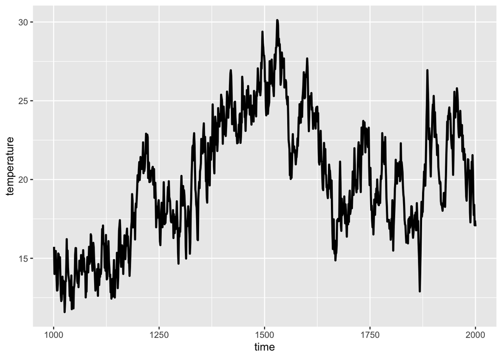

### 2.1.2 Creating a community

In order to create a community we define a set of $S$ species and in the following only two things differ among the species:

The optimum temperature for growth, such that some species have maximum intrinsic growth rate at higher temperatures and some have maximum intrinsic growth at lower temperatures. The optimum temperature for growth for each species in a community is drawn from a uniform distribution with a specific mean and range.

The interspecific interactions in the interaction matrix $alpha_{i,j}$. These are drawn from a normal distribution with mean zero and standard deviation $sd(alpha_{i,j})$.

### 2.1.3 Community composition treatments

Examples of randomly selected temperature optima.

```
[1] 10
```

[output not shown]

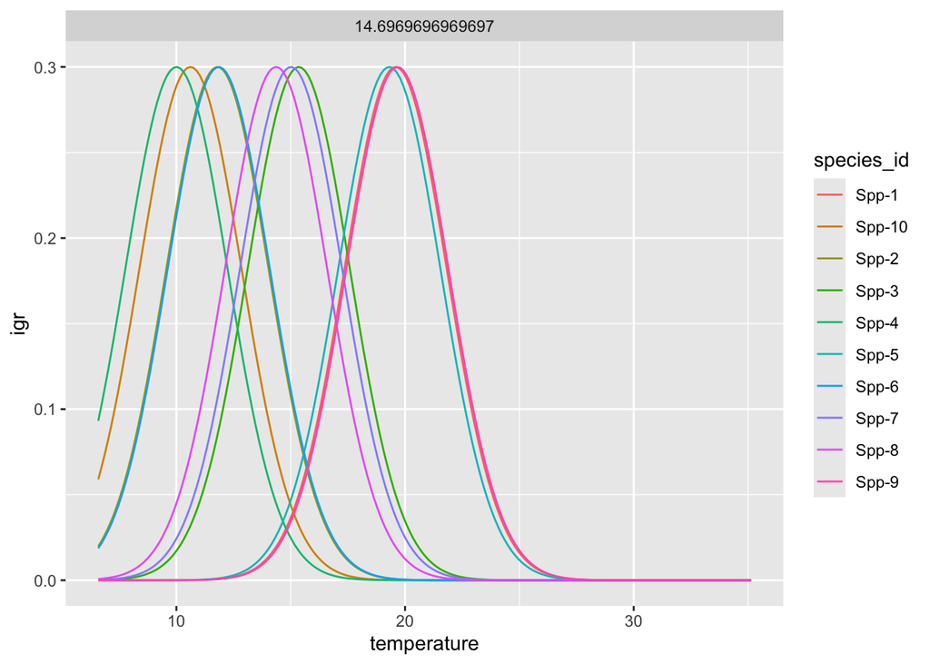

Examples of systematically selected temperature optima.

```
[1] 10
```

[output not shown]

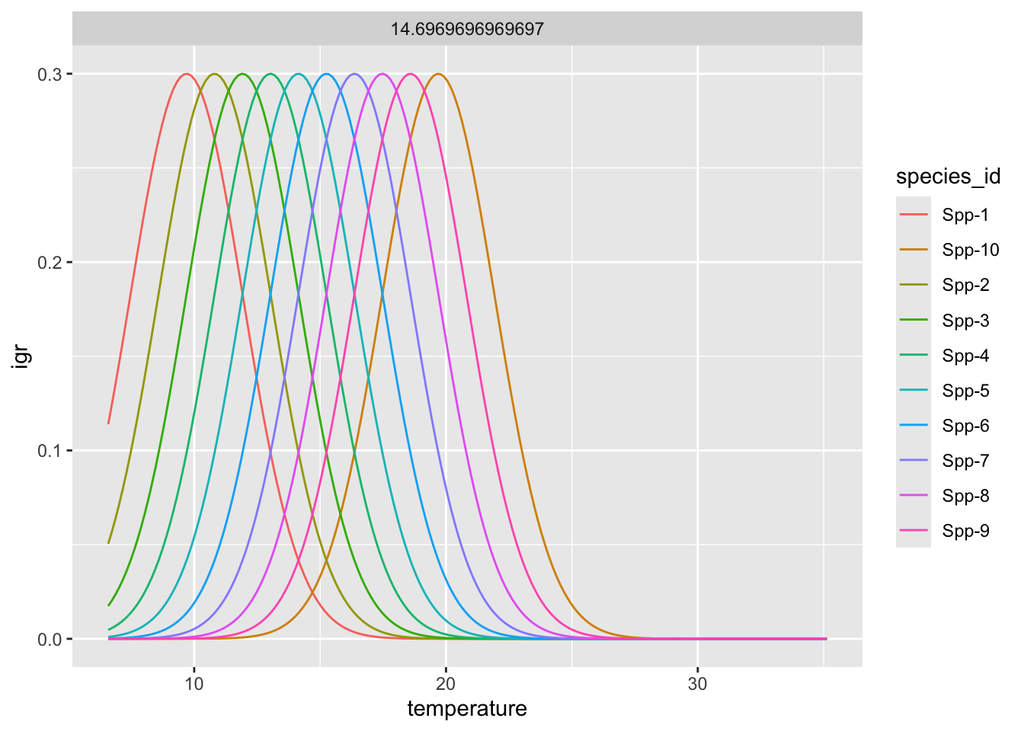

Each communities has a specified interaction strength standard deviation. When we set $sd(alpha_{i,j})$ = 0 then there are no interspecific interactions. Larger values of $sd(alpha_{i,j})$ mean that interspecific interactions are stronger.

## 2.2 Analyses

### 2.2.1 Species response traits

We calculated two types of species response trait. First was a response trait based on the temperature response curve of a species (i.e., as in Ross et al (2023)). For this trait, we calculated the effect of the perturbation on intrinsic growth rate (perturbation temperature intrinsic growth rate - control temperature intrinsic growth rate). This is analogous to the calculating the first derivative (slope) of the temperature response curve.

Second was a response trait based on the observed response of the species to the pulse perturbation in the community context. Hence this response trait depends on the direct effect of the pulse on a species, and also the indirect effects via other species in the community.

### 2.2.3 Community stability

This was calculated as the coefficient of variation of total community biomass.

# 3 Results

## 3.1 Some example dynamics

Here with evenly spaced temperature optima.

```
[1] 10
```

[output not shown]

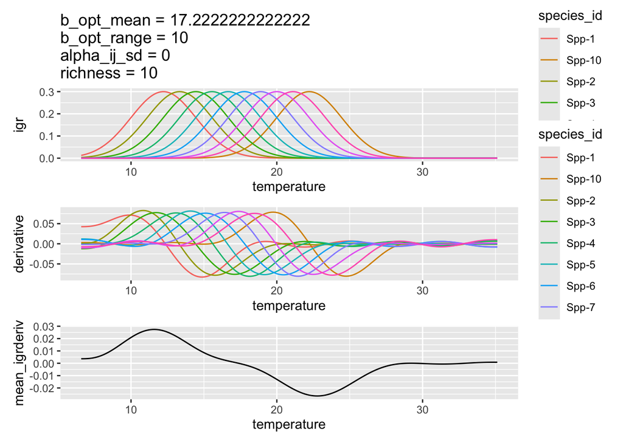

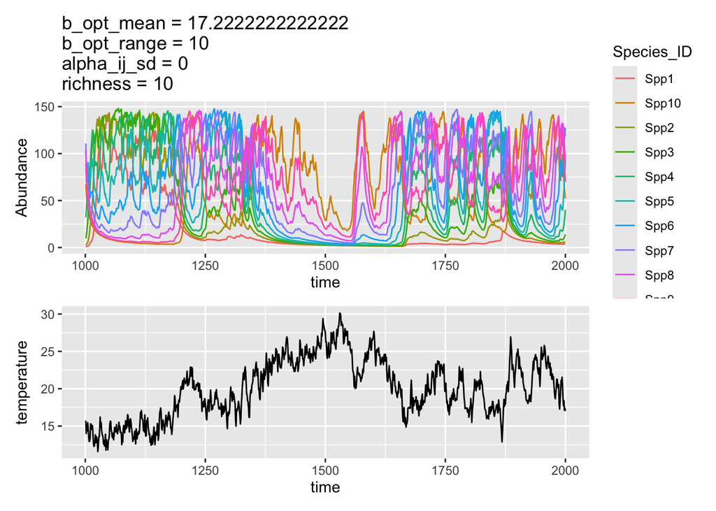

Here with random temperature optima:

```
[1] 10
```

[output not shown]

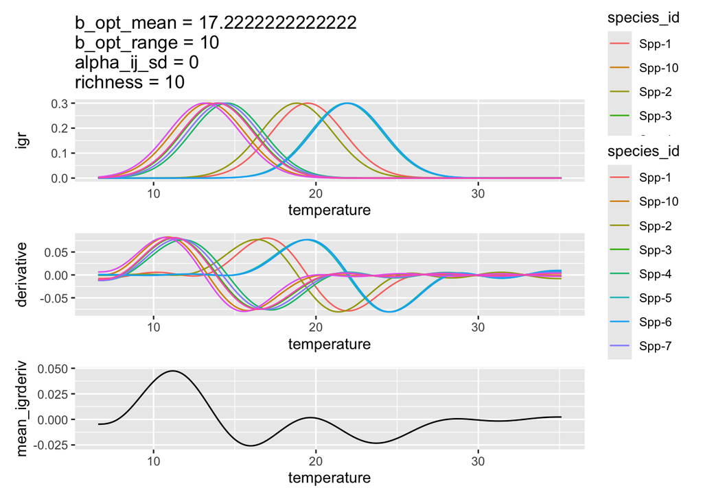

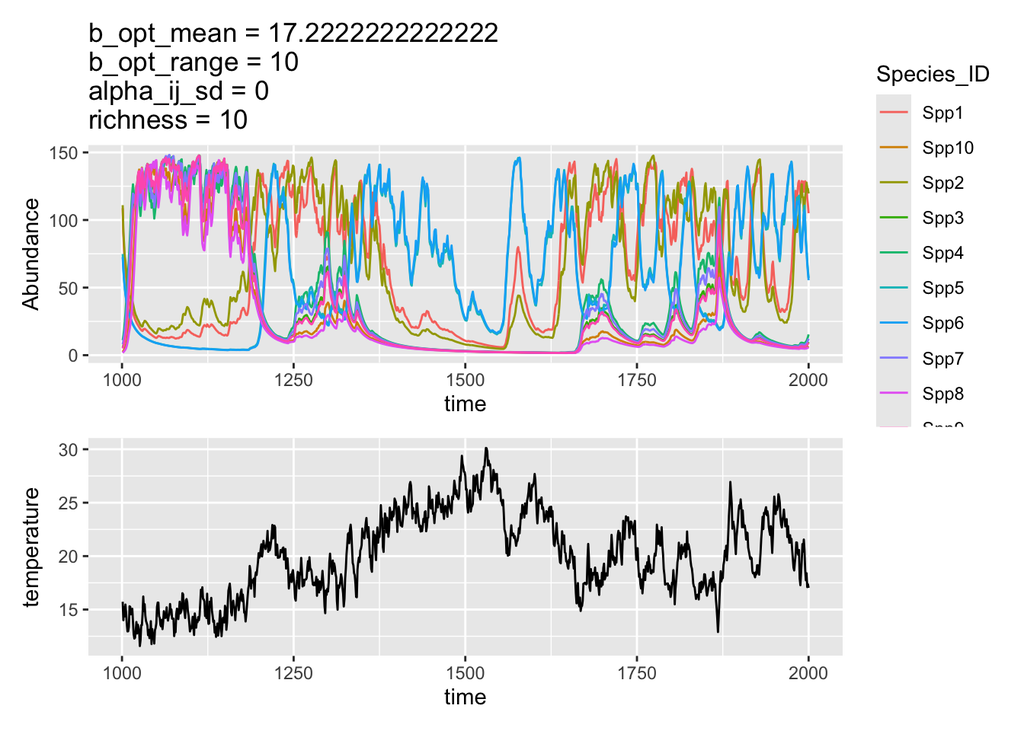

## 3.2 Stability and diversity

Evenly distributed traits and the same temperature series for every simulation:

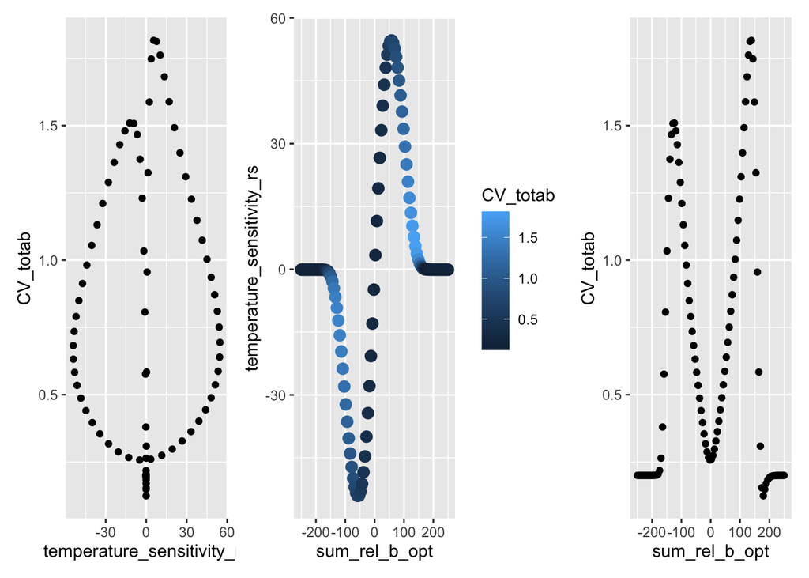

Evenly distributed traits and different temperature series for each replicate. E.g., when there are five replicates, there are five temperature times series.

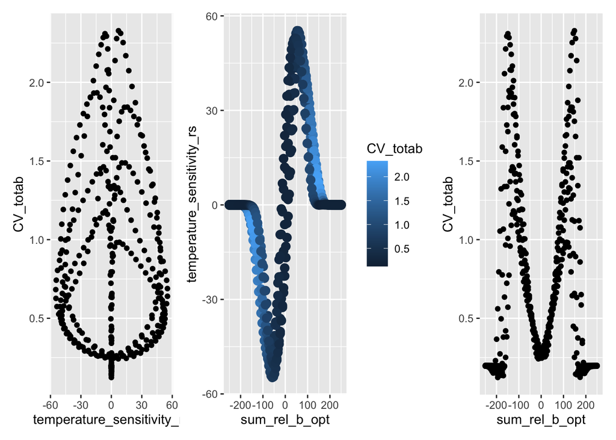

Randomly distributed traits and the same temperature series for every simulation:

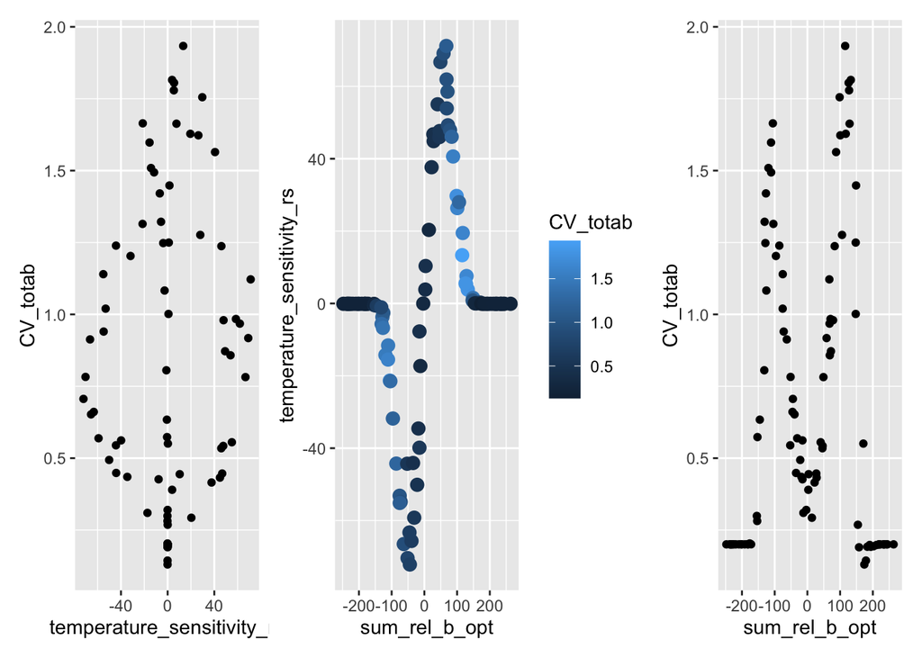

Randomly distributed traits and different temperature series for each replicate. E.g., when there are five replicates, there are five temperature times series.

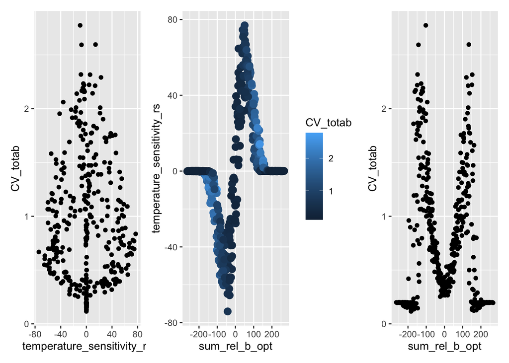

# 4 Interesting cases to look at

[figure not shown]

[figure not shown]